# 16.2: Smart Drug (robust estimation)

## Introduction

This is the example from Section 16.2 of Kruschke on the (fictitious) effect of the “smart drug”, this time using a Student t model for robust estimation. Make sure the “TwoGroupIQ.csv” file is in your project directory.

## Preliminaries

Load necessary packages:

```r
library(tidyverse)
library(rstan)
library(shinystan)
library(bayesplot)
```

Set Stan to save compiled code.

```r
rstan_options(auto_write = TRUE)
```

Set Stan to use parallel processing where possible.

```r
options(mc.cores = parallel::detectCores())
```

## Data

```r
IQ_data <- read_csv("TwoGroupIQ.csv")
IQ_data
```

| Score | Group |
| --- | --- |
| 102 | Smart Drug |
| 107 | Smart Drug |
| 92 | Smart Drug |
| 101 | Smart Drug |
| 110 | Smart Drug |
| 68 | Smart Drug |
| 119 | Smart Drug |
| 106 | Smart Drug |
| 99 | Smart Drug |
| 103 | Smart Drug |

[output cut: 110 more lines]

For this 1-sample test, we will only look at those who took the smart drug.

```r
IQ1_data <- IQ_data %>%
    filter(Group == "Smart Drug")
IQ1_data
```

| Score | Group |
| --- | --- |
| 102 | Smart Drug |
| 107 | Smart Drug |
| 92 | Smart Drug |
| 101 | Smart Drug |
| 110 | Smart Drug |
| 68 | Smart Drug |
| 119 | Smart Drug |
| 106 | Smart Drug |
| 99 | Smart Drug |
| 103 | Smart Drug |

[output cut: 53 more lines]

```r
N <- NROW(IQ1_data)
y <- IQ1_data$Score
stan_data <- list(N = N, y = y)
```

## Stan code

```stan
data {
    int<lower = 0> N;
    real<lower = 0> y[N];
}
transformed data {
    real<lower = 0> Rate;
    real<lower = 0> M;
    real<lower = 0> S;
    real<lower = 0> L;
    real<lower = 0> H;

    Rate = 1.0/29.0;
    M = 100;
    S = 100;
    L = 0;
    H = 1000;
}
parameters {
    real<lower = 0> nu_minus_one;
    real<lower = 0> mu;
    real<lower = 0> sigma;
}
transformed parameters {
    real<lower = 0> nu;

    nu = nu_minus_one + 1;
}
model {
    nu_minus_one ~ exponential(Rate);
    mu ~ normal(M, S);
    sigma ~ uniform(L, H);
    y ~ student_t(nu, mu, sigma);
}
generated quantities {
    real y_rep[N];

    for (n in 1:N) {
        y_rep[n] = student_t_rng(nu, mu, sigma);
    }
}
```

## Sampling from the model

```r
set.seed(11111)
fit_IQ_robust <- sampling(IQ_robust, data = stan_data, refresh = 0)
```

## Diagnosing the model

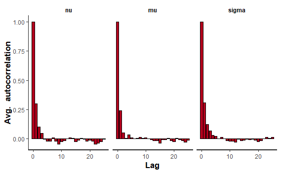

```r
plot(fit_IQ_robust, plotfun = "ac", pars = c("nu", "mu", "sigma"))
```

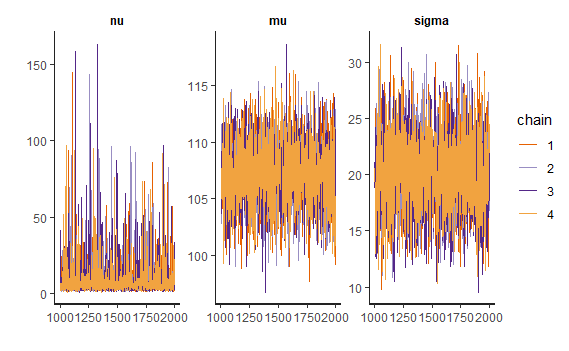

```r
plot(fit_IQ_robust, plotfun = "trace",
     pars = c("nu", "mu", "sigma"))
```

## Summarizing the model

```r
print(fit_IQ_robust, pars = c("nu", "mu", "sigma"))
```

```
Inference for Stan model: stan-f803d141014.
4 chains, each with iter=2000; warmup=1000; thin=1;
post-warmup draws per chain=1000, total post-warmup draws=4000.

        mean se_mean    sd   2.5%    25%    50%    75%  97.5% n_eff
nu      9.82    0.27 12.40   1.91   3.61   5.69  10.51  44.10  2094
mu    107.19    0.06  2.84 101.60 105.33 107.22 109.06 112.90  2289
sigma  19.89    0.08  3.47  13.43  17.42  19.80  22.34  26.81  1824
      Rhat
nu       1
mu       1
sigma    1

Samples were drawn using NUTS(diag_e) at Wed May 29 22:22:05 2019.
For each parameter, n_eff is a crude measure of effective sample size,
and Rhat is the potential scale reduction factor on split chains (at
convergence, Rhat=1).
```

## Visualizing the model

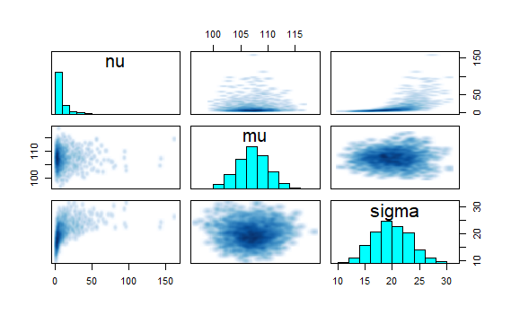

```r
pairs(fit_IQ_robust, pars = c("nu", "mu", "sigma"))
```

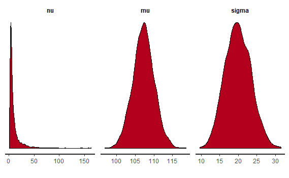

```r
plot(fit_IQ_robust, plotfun = "dens", pars = c("nu", "mu", "sigma"))
```

```
ci_level: 0.8 (80% intervals)
outer_level: 0.95 (95% intervals)
```

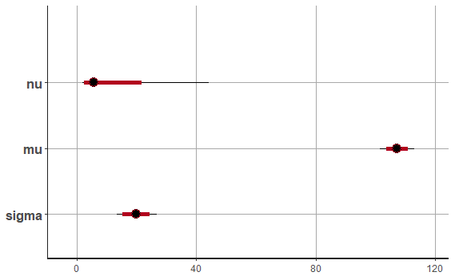

```r
plot(fit_IQ_robust, pars = c("nu", "mu", "sigma"))
```

## Examining the prior

```stan
data {
    int<lower = 0> N;
    real<lower = 0> y[N];
}
transformed data {
    real<lower = 0> Rate;
    real<lower = 0> M;
    real<lower = 0> S;
    real<lower = 0> L;
    real<lower = 0> H;

    Rate = 1.0/29.0;
    M = 100;
    S = 100;
    L = 0;
    H = 1000;
}
parameters {
    real<lower = 0> nu_minus_one;
    real<lower = 0> mu;
    real<lower = 0> sigma;
}
transformed parameters {
    real<lower = 0> nu;

    nu = nu_minus_one + 1;
}
model {
    nu_minus_one ~ exponential(Rate);
    mu ~ normal(M, S);
    sigma ~ uniform(L, H);
//    y ~ student_t(nu, mu, sigma);
}
```

```r
set.seed(11111)
fit_IQ_robust_prior <- sampling(IQ_robust_prior, data = stan_data, refresh = 0)
```

```
There were 2993 divergent transitions after warmup. Increasing adapt_delta above 0.8 may help. See
http://mc-stan.org/misc/warnings.html#divergent-transitions-after-warmupExamine the pairs() plot to diagnose sampling problems
```

```r
fit_IQ_robust_prior
```

```
Inference for Stan model: stan-f805a6447f.
4 chains, each with iter=2000; warmup=1000; thin=1;
post-warmup draws per chain=1000, total post-warmup draws=4000.

               mean se_mean     sd  2.5%    25%    50%    75%
nu_minus_one  28.84    1.01  28.71  0.89   7.71  19.85  40.24
mu           129.22    3.26  79.04 12.75  68.50 117.16 177.77
sigma        493.40   12.58 278.48 44.43 249.37 488.18 724.47
nu            29.84    1.01  28.71  1.89   8.71  20.85  41.24
lp__          12.00    0.06   1.37  8.71  11.20  12.28  13.04
              97.5% n_eff Rhat
nu_minus_one 106.04   813 1.00
mu           307.27   587 1.01
sigma        971.75   490 1.01
nu           107.04   813 1.00
lp__          13.83   487 1.01

Samples were drawn using NUTS(diag_e) at Wed May 29 22:23:38 2019.
For each parameter, n_eff is a crude measure of effective sample size,
and Rhat is the potential scale reduction factor on split chains (at
convergence, Rhat=1).
```

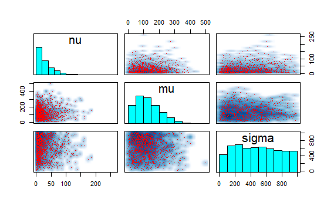

```r
pairs(fit_IQ_robust_prior, pars = c("nu", "mu", "sigma"))
```

```
ci_level: 0.8 (80% intervals)
outer_level: 0.95 (95% intervals)
```

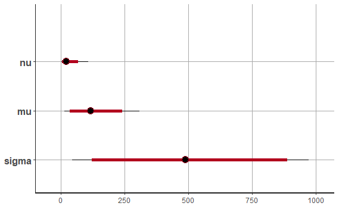

```r
plot(fit_IQ_robust_prior, pars = c("nu", "mu", "sigma"))
```

## Posterior predictive check

Extract predicted values:

```r
samples_IQ_robust <- extract(fit_IQ_robust)
y_rep <- samples_IQ_robust$y_rep
```

Graph values of $y$ against summaries of $y_{rep}$. There are lots of options for numerical data.

For the ones that generate lots of subgraphs, we’ll only compare the data to the first 5 replications.

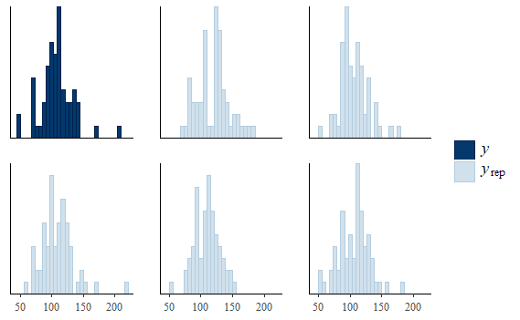

```r
ppc_hist(y, y_rep[1:5, ])
```

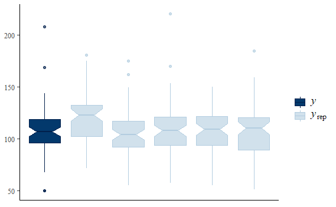

```r
ppc_boxplot(y, y_rep[1:5, ])
```

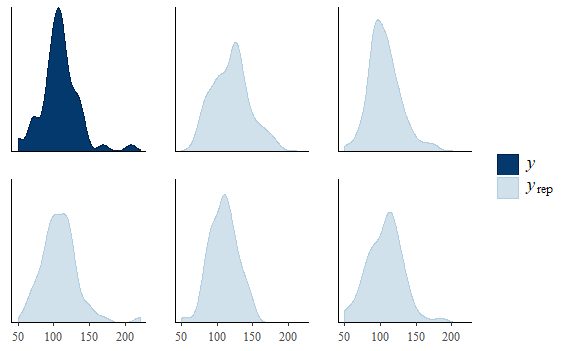

```r
ppc_dens(y, y_rep[1:5, ])
```

In an overlay, we can include a few more. (In theory, we could include all replications, but the function takes a long time to process.)

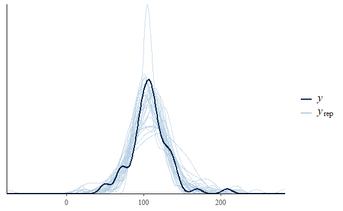

```r
ppc_dens_overlay(y, y_rep[1:30, ])
```

For test statistics, we can include all replications.

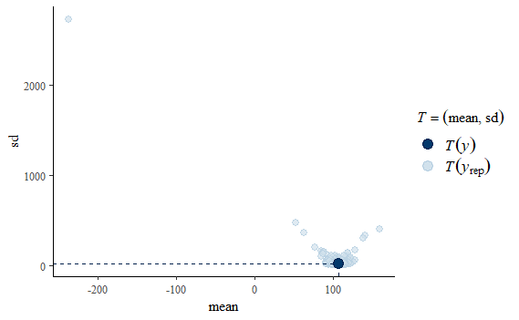

```r
ppc_stat_2d(y, y_rep)
```

Whoa! There’s one super-freaky sample. Some sleuthing shows that the crazy mean/sd is coming from from the 1514th set of sampled values of `y_rep`:

```r
y_rep[1514, ]
```

```
 [1]    116.79222    123.41931    118.88857     95.36574
 [5]    140.61069    108.54042     94.34612     97.69359
 [9]    119.49486     91.19018    105.38089     80.10360
[13]     95.42635    119.05697 -21491.77399    109.90423
[17]    122.63177     96.96282    101.72290    126.50847
[21]    117.45367     85.88951    103.52304     88.23233
[25]    100.28263    104.64405    105.81981    100.03632
[29]    111.58664     98.74338    107.35647     83.22282
[33]     35.62012     43.00801    103.42527    111.50627
[37]    102.60593     87.69518     96.59310    101.24972
[41]    103.54958    106.07613     87.84874     98.71082
[45]    137.49803    108.71800    108.96219     97.64785
[49]     88.57055    144.01064    146.24977    107.25808
[53]     97.92868    111.28802     67.97064    142.20807
[57]    133.77731    142.32882    117.37273    123.66269
[61]    101.34838    127.51202    109.24989
```

It’s the crazy outlier in the 15th spot in this list.

```r
mean(y_rep[1514, ])
```

```
[1] -236.9761
```

```r
sd(y_rep[1514, ])
```

```
[1] 2721.121
```

There’s nothing too weird about the combination of `(nu, mu, sigma)` from which this data was simulated:

```r
samples_IQ_robust$nu[1514]
```

```
[1] 1.643238
```

```r
samples_IQ_robust$mu[1514]
```

```
[1] 104.164
```

```r
samples_IQ_robust$sigma[1514]
```

```
[1] 12.84032
```

The value of `nu` is on the smaller side (but by no means the smallest), so this is a wide t distribution, and the idea is that it’s possible, just by chance, to get unusual outliers in t distributions with low values of $\nu$ from time to time.

This one weird value does not prevent the vast majority of our posterior predictive simulations from looking like a much better fit to our data.

The following intervals, of course, don’t show the effect of the wacky simulated outlier:

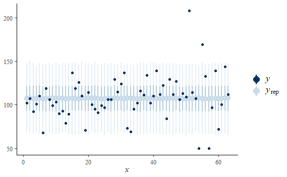

```r
ppc_intervals(y, y_rep)
```

## ShinyStan

Run the following code from the Console:

```
launch_shinystan(fit_IQ_robust)
```